# Multiscale GWR using top down scale approaches

Ghislain Geniaux and Cesar Martinez

2025-12-03

## Introduction

In this release, we introduce several estimation methods aimed at accommodating bandwidths that may vary for each variable and adapt according to location. Following the initial works of Yang et al (2011) for developing a Flexible Bandwidth approach for GWR, Yang (2014); Leong and Yue (2017); Lu et al (2017); Fotheringham et al (2017) (hereafter FT2017) made a significant contribution to this issue by allowing for the identification of different optimal bandwidths for each variable j, using jacobi iteration or backfitting algorithm. However existing implementation of the multiscale GWR using backfitting methods demonstrates sluggish performance and is only suitable for datasets containing fewer than 2500 observations and fewer than 6 explanatory variables. To achieve this for larger sample size, we rely on an innovative approach that departs from the optimization of a single optimal bandwidth and instead utilizes a decreasing series of bandwidths in a manner reminiscent of gradient boosting algorithms.

The gwr_multiscale function directly transcribes the backfitting procedure used in the gwr.multiscale of the GWmodel package. It leverages the mgwrsar estimation framework to reduce estimation time and enables the estimation of multiscale GWR with spatial dependence. The criterion used for finding optimal (univariate) bandwidth stopping criteria is based on AICc while RMSE is used as stopping criteria for the backfitting algorithm. For this method a demo is provided only for the analyses of in sample Betas estimates.

The tds_mgwr is an innovative approach for multiscale GWR that departs from the original backfitting procedure proposed by Fotheringham and al. (2017) by employing a set of decreasing bandwidths without fully optimizing the bandwidth at each iteration of the backfitting algorithm. It leverages the top-down scale method, employing a backfitting procedure only to preserve the favorable properties observed in the univariate case. This drastically reduces the number of estimations, and convergence is ensured by a test procedure conducted in parallel on a batch of ascending and descending bandwidths. Along the algorithm the full AICc is computed using Yu et al. (2020) proposition.

The atds_mgwr procedure constitutes a second step after the estimation of tds_mgwr, once the optimal bandwidths for each variable are known. It launches a backfitting on each variable to perform an univariate tds_gwr estimation to test if adapting the bandwidth based on location improves the estimations. (The tds_gwr algorithm implements an innovative Top-Down Scale (TDS) strategy for univariate GWR, allowing for location-specific bandwidth adaptation. It leverages a gradient boosting framework in conjunction with a backfitting procedure to refine bandwidth optimization.)

Both tds_mgwr and atds_mgwr imply several $n\times n$ matrix multiplications for computing the hat matrix, using Wu et al 2018 for backfitting part and Buhlmann and Hothorn (2007) for the gradient boosting part.

### TDS_MGWR Wrapper Function

The estimation of Multiscale Geographically Weighted Regression models (MGWR) and their Spatio-Temporal extensions (MGTWR) is performed using the `TDS_MGWR` wrapper function. This function implements the **Top-Down Scale (TDS)** approach, designed to efficiently identify covariate-specific bandwidths. It accepts:

- A dataframe and a matrix of coordinates (spatial or spatio-temporal), or
- Spatial objects such as `sf`, `SpatialPointsDataFrame`, etc.

#### Key Features and Notes

- **Multiscale Estimation (TDS Algorithm):** Unlike standard GWR where a single bandwidth applies to all variables, this wrapper estimates a unique optimal bandwidth for each covariate. It uses a **Backfitting algorithm** combined with a **Top-Down Scale** strategy: it starts with large bandwidths (global) and iteratively tests smaller bandwidths from a decreasing sequence to avoid local optima and the “yo-yo” effect.
- **Adaptive Boosting (ATDS):** By setting `Model='atds_mgwr'`, the function performs a second stage of estimation called **Adaptive Top-Down Scale (ATDS)**. After the initial TDS backfitting (Stage 1), this “boosting” phase refines the estimates by allowing the bandwidth of each covariate to vary locally across space (adaptive bandwidths per location), providing a flexible fit for complex non-stationary processes.
- **Spatio-Temporal Multiscale (MGTWR):** The wrapper fully supports **Space-Time** multiscale modeling (`Type='GDT'`). It simultaneously optimizes a spatial bandwidth ($h_s$) and a temporal bandwidth ($h_t$) for each covariate, handling the interaction between space and time scales automatically.
- **Flexible Initialization:** The backfitting process can be initialized using an OLS model, a standard GWR/GTWR, or a pre-computed model (`control_tds$init_model`). This flexibility helps in speeding up convergence for complex datasets.
- **Optimization & Parallel Computing:** The function is optimized for performance using `Rcpp`, `RcppAramdillo` and `RcppEigen` for the core weighted regressions. It use `doParallel` for efficient bandwidth searches on multi-core systems.
- **Control Parameters:** Specific tuning of the multiscale algorithm is managed via the `control_tds` list argument, which allows users to define:
  - The granularity of the bandwidth search (`nns`).
  - Convergence tolerances (`tol`) and maximum iterations (`maxiter`, `nrounds`).
  - Criteria for model selection (AICc).

## Data example: simulated DGP with complex spatial patterns.

In the following example, the simu_multiscale allow to simulate the DGP proposed by Geniaux 2025 (Top down scale approaches for multiscale GWR and other semi-parametric partially linear varying coefficient regression with multiple locally-self-adaptive bandwidths, in prep) illustrated in the next figure.

```r
library(mgwrsar)
library(dplyr)
n=1000
simu1=simu_multiscale(n,myseed = 1,config_snr=0.9,config_beta='default',config_eps='normal')
mydata=simu1$mydata
coords=simu1$coords
TRUEBETA<-as.matrix(mydata[,c('Beta1','Beta2','Beta3','Beta4')],ncol=4)
myformula<-as.formula('Y ~ X1 + X2 + X3')
```

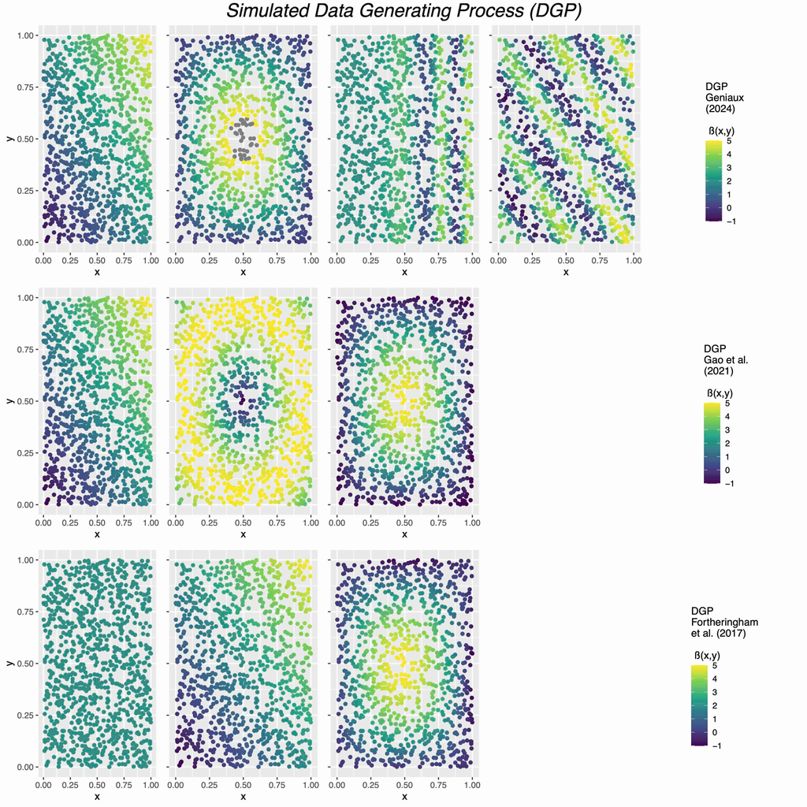

GG2025 multiscale DGP

## Estimation of multiscale GWR like models.

### GWR estimates as benchmark

```r
############
## GWR as a benshmark model (we use the whole dataset for estimation)
############
res1=golden_search_bandwidth(formula=myformula,Ht=NULL,data = mydata,coords=coords, fixed_vars=NULL,kernels=c('gauss'), Model = 'GWR',control=list(verbose=F,NN=300,criterion='AICc',adaptive=F),lower.bound=0, upper.bound=1,tolerance=0.001,show_progress = FALSE)
res1$minimum
```

```
## [1] 0.04559156
```

```r
res1$objective
```

```
## [1] 4807.38
```

```r
modelGWR1<-res1$model
summary(modelGWR1)
```

```
## ------------------------------------------------------
## Call:
## MGWRSAR(formula = formula, data = data, coords = coords, fixed_vars = fixed_vars,
##     kernels = kernels, H = c(res, Ht), Model = Model, control = control_o)
##
## Model: GWR
## ------------------------------------------------------
## Kernels Configuration:
##    Spatial Kernel  : gauss (Fixed / Distance)
## ------------------------------------------------------
## Bandwidth Configuration:
##    Spatial Bandwidth (H): 0.05
## ------------------------------------------------------
## Model Settings:
##    Computation time: 0.029 sec
##    Use of Target Points: NO
##    Use of rough kernel approximation: YES (300 neighbors)
##    Parallel computing: FALSE (ncore = 1)
##    Number of data points: 1000
## ------------------------------------------------------
## Coefficients Summary:
##    [Varying Parameters]
##    Intercept            X1                X2                X3
##  Min.   :-1.147   Min.   :-0.8295   Min.   :-2.6726   Min.   :-4.39132
##  1st Qu.: 1.111   1st Qu.: 1.0660   1st Qu.:-0.3414   1st Qu.:-1.69263
##  Median : 2.033   Median : 2.0925   Median : 0.1939   Median : 0.15229
##  Mean   : 1.990   Mean   : 2.2149   Mean   : 0.2355   Mean   :-0.03034
##  3rd Qu.: 2.760   3rd Qu.: 3.2249   3rd Qu.: 0.9090   3rd Qu.: 1.57035
##  Max.   : 6.029   Max.   : 5.5941   Max.   : 3.5929   Max.   : 4.38507
## ------------------------------------------------------
## Diagnostics:
##    Effective degrees of freedom: 726.83
##    AICc: 4807.38
##    Residual sum of squares: 3371.71
##    RMSE: 1.8362
## ------------------------------------------------------
```

```r
### Beta RMSE
Beta_RMSE=apply((modelGWR1@Betav-TRUEBETA %>% as.data.frame()),2,rmse)
Beta_RMSE
```

```
##     Beta1     Beta2     Beta3     Beta4
## 0.4951005 0.5190067 0.9916124 1.4113384
```

```r
mean(Beta_RMSE)
```

```
## [1] 0.8542645
```

```r
res1$model@AICc
```

```
## [1] 4807.38
```

```r
## plot
p<-plot(res1$model,type='B_coef',var='X3')
# Size Optimisation for the vignette
p<-plotly::partial_bundle(p)
p
```

[interactive chart not shown]

### multiscale_gwr estimates

The **multiscale_gwr** function implements the backfitting algorithm proposed by Fotheringham et al. (2017). Key features of this implementation include:

- Bandwidth Optimization: The algorithm searches for the optimal bandwidth at each iteration of the backfitting process. The search continues until no change in bandwidth occurs for five consecutive iterations. The final stopping criterion is based on the relative change in Root Mean Squared Error (RMSE).
- Initialization: The backfitting algorithm starts with coefficients obtained from a standard GWR model (init=‘GWR’).
- AICc Calculation: The option get_AICg=TRUE enables the computation of the corrected Akaike Information Criterion (AICc) for the final model using the method of Yu et al. (2020).

```r
############
## multiscale_gwr
############

model_multiscale_gwr <-multiscale_gwr(formula=myformula,data=mydata,coords=coords,kernels='gauss',control_mgwr=list(verbose=T,get_AIC=TRUE,init='GWR'),control=list(adaptive=F,verbose=F))
```

```
## H0= 0.04546948
## AICc= 4807.368  RMSE= 1.832318
##
##  backfitting   Intercept    X1    X2    X3
##  iter  1  H  0.1236359 0.06586641 0.03490549 0.03258149  RMSE= 1.628426  delta_rmse  0.6785539  AICg= 4569.35  stable 0 0 0 0
##
##  backfitting   Intercept    X1    X2    X3
##  iter  2  H  0.124608 0.06307946 1.36521 0.03641194  RMSE= 2.301496  delta_rmse  -0.4133257  AICg= 4882.729  stable 0 0 0 0
##
##  backfitting   Intercept    X1    X2    X3
##  iter  3  H  0.1447308 0.07483224 1.36521 0.03634757  RMSE= 2.300419  delta_rmse  0.0004682313  AICg= 4856.648  stable 0 0 1 0
##
##  backfitting   Intercept    X1    X2    X3
##  iter  4  H  0.1457452 0.07459003 1.36521 0.0363452  RMSE= 2.300592  delta_rmse  -7.511257e-05  AICg= 4856.351  stable 0 0 2 0
##
##  backfitting   Intercept    X1    X2    X3
##  iter  5  H  0.1459951 0.07453515 1.36521 0.03634565  RMSE= 2.300686  delta_rmse  -4.089934e-05  AICg= 4856.411  stable 0 0 3 0
##
##  backfitting   Intercept    X1    X2    X3
##  iter  6  H  0.1460523 0.07452345 1.36521 0.03634565  RMSE= 2.300708  delta_rmse  -9.521962e-06  AICg= 4856.431  stable 0 0 4 1
##
##  backfitting   Intercept    X1    X2    X3
##  iter  7  H  0.1460647 0.07452108 1.36521 0.0363461  RMSE= 2.300719  delta_rmse  -5.003814e-06  AICg= 4856.435  stable 0 0 5 0
##
##  backfitting   Intercept    X1    X2    X3
##  iter  8  H  0.1460676 0.0745208 1.36521 0.0363461  RMSE= 2.300721  delta_rmse  -6.628978e-07  AICg= 4856.436  stable 0 0 6 1
##
##  backfitting   Intercept    X1    X2    X3
##  iter  9  H  0.1460683 0.0745208 1.36521 0.0363461  RMSE= 2.300721  delta_rmse  -2.066053e-07  AICg= 4856.437  stable 0 1 7 2
##
##  backfitting   Intercept    X1    X2    X3
##  iter  10  H  0.1460683 0.0745208 1.36521 0.0363461  RMSE= 2.300721  delta_rmse  -2.852397e-08  AICg= 4856.437  stable 1 2 8 3
##
##  backfitting   Intercept    X1    X2    X3
##  iter  11  H  0.1460683 0.0745208 1.36521 0.0363461  RMSE= 2.300721  delta_rmse  -4.84375e-09  AICg= 4856.437  stable 2 3 9 4
##
##  backfitting   Intercept    X1    X2    X3
##  iter  12  H  0.1460683 0.0745208 1.36521 0.0363461  RMSE= 2.300721  delta_rmse  -8.779978e-10  AICg= 4856.437  stable 3 4 10 5
##
##  backfitting   Intercept    X1    X2    X3
##  iter  13  H  0.1460683 0.0745208 1.36521 0.0363461  RMSE= 2.300721  delta_rmse  -1.653339e-10  AICg= 4856.437  stable 4 5 11 6
##
##  backfitting   Intercept    X1    X2    X3
##  iter  14  H  0.1460683 0.0745208 1.36521 0.0363461  RMSE= 2.300721  delta_rmse  -3.19009e-11  AICg= 4856.437  stable 5 6 12 7
## Time =  71.244
```

```r
# Computation time with macbookpro M1
model_multiscale_gwr@ctime
```

```
## elapsed
##  71.244
```

```r
### Beta RMSE
Beta_RMSE=apply((model_multiscale_gwr@Betav-TRUEBETA %>% as.data.frame()),2,rmse)
Beta_RMSE
```

```
##     Beta1     Beta2     Beta3     Beta4
## 0.2792403 0.4296002 1.6060919 1.2964795
```

```r
mean(Beta_RMSE)
```

```
## [1] 0.902853
```

```r
model_multiscale_gwr@AICc
```

```
## [1] 4856.437
```

### tds_mgwr estimates

The **tds_mgwr** algorithm is designed to achieve the same objectives as multiscale GWR, specifically to identify a unique bandwidth for each variable. The model is defined as:

$y_{i}=\sum_{k=1}^{K}\beta_{k}(u_{i},v_{i};K(h_k))x_{ij}+\epsilon_{i}$

#### Key Features:

- Bandwidth Sequence: The algorithm uses a geometrically decreasing sequence of bandwidths (default: 30 values) during the backfitting process. The starting bandwidth is the largest, corresponding to an Ordinary Least Squares (OLS) estimate.
- Bandwidth Selection: At each step $m$ of the backfitting algorithm, the bandwidth $h_m$ is adjusted (typically reduced). The algorithm evaluates whether to retain $h_m$ or revert to previous value based on the AICc criterion.
- Efficiency: Instead of performing a full optimization at each iteration, the algorithm computes the AICc for up to five bandwidth values in parallel:
  - The most recent optimal bandwidth for the variable.
  - The preceding bandwidth value (upper bandwidth $h_{m-1}$).
  - The bandwidth $h_m$.
  - The subsequent bandwidth value (lower bandwidth $h_{m+1}$).
  - The lowest bandwidth across all variables.

```r
############
### tds_mgwr
############
# model estimate
model_tds_mgwr=TDS_MGWR(formula=myformula,Model='tds_mgwr',data=mydata,coords=coords,kernels='gauss',fixed_vars=NULL,control_tds=list(nns=25,get_AIC=F,verbose=T,doMC=T,ncore=8),control=list(adaptive=F))
```

```
## Running Top-Down Scale MGWR
```

```
## Initializing starting model...
```

```
##  Estimating starting model of type: OLS
```

```
##     Fitting global OLS model...
```

```
##
##  i = 1  Starting model
##
##
## ########################################################################
##  STAGE 1 : find unique bandwidth for each covariate
##  using Top Down Scale Approach with backfitting for Type = GD  ...
## ########################################################################
##
##
##   1  Intercept  X1  X2  X3
##  stable  0 1 1 1  delta_rmse  0.006235666  rmse  4.056133
##
##  H = 1.060343 1.369055 1.369055 1.369055
##
##   2  Intercept  X1  X2  X3
##  stable  0 2 2 0  delta_rmse  0.006360812  rmse  4.030332
##
##  H = 0.7474158 1.369055 1.369055 0.7474158
##
##   3  Intercept  X1  X2  X3
##  stable  0 0 0 0  delta_rmse  0.007480846  rmse  4.000182
##
##  H = 0.6189216 0.6189216 0.6189216 0.6189216
##
##   4  Intercept  X1  X2  X3
##  stable  0 0 0 0  delta_rmse  0.007208017  rmse  3.971349
##
##  H = 0.5230223 0.5230223 0.5230223 0.5230223
##
##   5  Intercept  X1  X2  X3
##  stable  0 0 0 0  delta_rmse  0.00975506  rmse  3.932608
##
##  H = 0.4400547 0.4400547 0.4400547 0.4400547
##
##   6  Intercept  X1  X2  X3
##  stable  0 0 0 0  delta_rmse  0.01229372  rmse  3.884262
##
##  H = 0.3712995 0.3712995 0.3712995 0.3712995
##
```

[output cut: 85 more lines]

```
##   24  Intercept  X1  X2  X3
##  stable  0 1 1 0  delta_rmse  0.04977438  rmse  1.57454
##
##  H = 0.1232769 0.06496041 0.03461749 0.02971105
##
##   25  Intercept  X1  X2  X3
##  stable  1 2 2 1  delta_rmse  0.002608808  rmse  1.570432
##
##  H = 0.1232769 0.06496041 0.03461749 0.02971105
##
##   26  Intercept  X1  X2  X3
##  stable  2 3 3 2  delta_rmse  0.0009568923  rmse  1.568929
##
##  H = 0.1232769 0.06496041 0.03461749 0.02971105
##  Time =  38.57
```

```r
## summary
summary(model_tds_mgwr)
```

```
## ------------------------------------------------------
## Call:
## TDS_MGWR(formula = myformula, data = mydata, coords = coords,
##     Model = "tds_mgwr", kernels = "gauss", fixed_vars = NULL,
##     control_tds = list(nns = 25, get_AIC = F, verbose = T, doMC = T,
##         ncore = 8), control = list(adaptive = F))
##
## Model: tds_mgwr
## ------------------------------------------------------
## Kernels Configuration:
##    Spatial Kernel  : gauss (Fixed / Distance)
## ------------------------------------------------------
## Bandwidth Configuration:
##    [TDS] Covariate-Specific Bandwidths:
##  Variable  Spatial_H
##  Intercept 0.12
##  X1        0.06
##  X2        0.03
##  X3        0.03
## ------------------------------------------------------
## Model Settings:
##    Computation time: 38.57 sec
##    Use of Target Points: NO
##    Use of rough kernel approximation: NO
##    Parallel computing: TRUE (ncore = 8)
##    Number of data points: 1000
## ------------------------------------------------------
## Coefficients Summary:
##    [Varying Parameters]
##    Intercept             X1                X2                X3
##  Min.   :-0.5411   Min.   :-0.3581   Min.   :-3.1434   Min.   :-5.28412
##  1st Qu.: 1.4041   1st Qu.: 1.2865   1st Qu.:-0.3232   1st Qu.:-2.13102
##  Median : 2.0675   Median : 2.1044   Median : 0.3016   Median : 0.23419
##  Mean   : 2.0228   Mean   : 2.3022   Mean   : 0.2805   Mean   :-0.01355
##  3rd Qu.: 2.6702   3rd Qu.: 3.2101   3rd Qu.: 1.0179   3rd Qu.: 2.02717
##  Max.   : 4.4234   Max.   : 4.9335   Max.   : 3.2856   Max.   : 4.92100
## ------------------------------------------------------
## Diagnostics:
##    Residual sum of squares:
##    RMSE: 1.5689
## ------------------------------------------------------
```

```r
## plot
p<-plot(model_tds_mgwr,type='B_coef',var='X3')
# Size Optimisation for the vignette
p<-plotly::partial_bundle(p)
p
```

[interactive chart not shown]

```r
### Beta RMSE
Beta_RMSE=apply((model_tds_mgwr@Betav-TRUEBETA %>% as.data.frame()),2,rmse)
Beta_RMSE
```

```
##     Beta1     Beta2     Beta3     Beta4
## 0.2386785 0.3986245 0.8200604 1.1142869
```

```r
mean(Beta_RMSE)
```

```
## [1] 0.6429126
```

```r
model_tds_mgwr@AICc
```

```
## numeric(0)
```

### atds_mgwr estimates

The **atds_mgwr algorithm** extends tds_mgwr by incorporating location-specific bandwidths, enabling local adaptation and improved estimation accuracy. The model is defined as:

$y_{i}=\sum_{k=1}^{K}\beta_{k}(u_{i},v_{i};K(h_k(u_i,v_i)))x_{ij}+\epsilon_{i}$

The **atds_mgwr** algorithm integrates a backfitting approach with a univariate GWR gradient boosting algorithm. Unlike **tds_mgwr**, which applies GWR at each iteration of the backfitting process, **atds_mgwr** employs a gradient boosting GWR that follows a sequence of decreasing bandwidths (using the same sequence as in **tds_mgwr**). For further details, see Geniaux (2025).

#### Key Features:

- Initialization: The algorithm uses the **tds_mgwr** estimates as the starting model (model_stage1=model_tds_mgwr).
- Gradient Boosting: Instead of a standard GWR, the algorithm **atds_mgwr** employs a gradient boosting GWR with a sequence of decreasing bandwidths. This approach improves model flexibility and accuracy.
- Stopping Criterion: Due to the limitations of using relative RMSE in gradient boosting, the algorithm relies on the global AICc proposed by Yu and Fotheringham (2020). This requires estimating the hat matrix at each boosting iteration using the approximation by Bühlmann and Hothorn (2007).
- Computational Considerations: The computation of the hat matrix involves $n \times n$ matrix storage and multiplication, which can be time-intensive. To mitigate this, the number of backfitting rounds is limited (e.g., 3 rounds in this example).

The **atds_mgwr** algorithm significantly improves estimation accuracy compared to **tds_mgwr**:

```r
############
## atds_mgwr
############

model_atds_mgwr=TDS_MGWR(formula=myformula,Model='atds_mgwr',data=mydata,coords=coords,kernels='gauss',fixed_vars=NULL,control_tds=list(nns=25,verbose=T,doMC=T,ncore=8),control=list(adaptive=F))
```

```
## Running Top-Down Scale MGWR
```

```
## Initializing starting model...
```

```
##  Estimating starting model of type: OLS
```

```
##     Fitting global OLS model...
```

```
##
##  i = 1  Starting model
##
##
## ########################################################################
##  STAGE 1 : find unique bandwidth for each covariate
##  using Top Down Scale Approach with backfitting for Type = GD  ...
## ########################################################################
##
##
##   1  Intercept AICc :  5647.698  X1 AICc :  5647.698  X2 AICc :  5647.698  X3 AICc :  5647.697
##  delta_AICc:  0.001970473  AICc :  5647.697  stable  0 1 1 1  delta_rmse  0.006235666  rmse  4.056133
##
##  H = 1.060343 1.369055 1.369055 1.369055
##
##   2  Intercept AICc :  5636.96  X1 AICc :  5636.96  X2 AICc :  5636.96  X3 AICc :  5635.926
##  delta_AICc:  0.002084228  AICc :  5635.926  stable  0 2 2 0  delta_rmse  0.006360812  rmse  4.030332
##
##  H = 0.7474158 1.369055 1.369055 0.7474158
##
##   3  Intercept AICc :  5627.446  X1 AICc :  5625.463  X2 AICc :  5624.118  X3 AICc :  5623.507
##  delta_AICc:  0.002203417  AICc :  5623.507  stable  0 0 0 0  delta_rmse  0.007480846  rmse  4.000182
##
##  H = 0.6189216 0.6189216 0.6189216 0.6189216
##
##   4  Intercept AICc :  5614.362  X1 AICc :  5611.889  X2 AICc :  5611.542  X3 AICc :  5610.743
##  delta_AICc:  0.00226984  AICc :  5610.743  stable  0 0 0 0  delta_rmse  0.007208017  rmse  3.971349
##
##  H = 0.5230223 0.5230223 0.5230223 0.5230223
##
##   5  Intercept AICc :  5600.289  X1 AICc :  5595.274  X2 AICc :  5594.873  X3 AICc :  5593.677
##  delta_AICc:  0.003041748  AICc :  5593.677  stable  0 0 0 0  delta_rmse  0.00975506  rmse  3.932608
##
##  H = 0.4400547 0.4400547 0.4400547 0.4400547
##
##   6  Intercept AICc :  5583.354  X1 AICc :  5574.65  X2 AICc :  5574.172  X3 AICc :  5572.531
##  delta_AICc:  0.003780175  AICc :  5572.531  stable  0 0 0 0  delta_rmse  0.01229372  rmse  3.884262
##
##  H = 0.3712995 0.3712995 0.3712995 0.3712995
##
```

[output cut: 85 more lines]

```
##   24  Intercept AICc :  4560.797  X1 AICc :  4560.213  X2 AICc :  4556.981  X3 AICc :  4569.348
##  delta_AICc:  -0.002372854  AICc :  4569.348  stable  0 1 1 0  delta_rmse  0.04977438  rmse  1.57454
##
##  H = 0.1232769 0.06496041 0.03461749 0.02971105
##
##   25  Intercept AICc :  4568.82  X1 AICc :  4568.098  X2 AICc :  4563.12  X3 AICc :  4562.11
##  delta_AICc:  0.001583881  AICc :  4562.11  stable  1 2 2 1  delta_rmse  0.002608808  rmse  1.570432
##
##  H = 0.1232769 0.06496041 0.03461749 0.02971105
##
##   26  Intercept AICc :  4562.06  X1 AICc :  4562.138  X2 AICc :  4560.952  X3 AICc :  4560.564
##  delta_AICc:  0.0003389045  AICc :  4560.564  stable  2 3 3 2  delta_rmse  0.0009568923  rmse  1.568929
##
##  H = 0.1232769 0.06496041 0.03461749 0.02971105
##  Time =  60.488
```

```
## Running Stage 2 (ATDS-MGWR boosting)...
```

```
## Start stage 2 :
## ------------------------------------------------------
## Call:
## TDS_MGWR(formula = myformula, data = mydata, coords = coords,
##     Model = "atds_mgwr", kernels = "gauss", fixed_vars = NULL,
##     control_tds = list(nns = 25, verbose = T, doMC = T, ncore = 8),
##     control = list(adaptive = F))
##
## Model: atds_mgwr
## ------------------------------------------------------
## Kernels Configuration:
##    Spatial Kernel  : gauss (Fixed / Distance)
## ------------------------------------------------------
## Bandwidth Configuration:
##    [ATDS] Bandwidth correction during stage 2:
##  Variable  Spatial_H
##  Intercept 0.12
##  X1        0.06
##  X2        0.03
##  X3        0.03
## ------------------------------------------------------
## Model Settings:
##    Computation time: 60.488 sec
##    Use of Target Points: NO
##    Use of rough kernel approximation: NO
##    Parallel computing: TRUE (ncore = 8)
##    Number of data points: 1000
## ------------------------------------------------------
## Coefficients Summary:
##    [Varying Parameters]
##    Intercept             X1                X2                X3
##  Min.   :-0.5411   Min.   :-0.3581   Min.   :-3.1434   Min.   :-5.28412
##  1st Qu.: 1.4041   1st Qu.: 1.2865   1st Qu.:-0.3232   1st Qu.:-2.13102
##  Median : 2.0675   Median : 2.1044   Median : 0.3016   Median : 0.23419
##  Mean   : 2.0228   Mean   : 2.3022   Mean   : 0.2805   Mean   :-0.01355
##  3rd Qu.: 2.6702   3rd Qu.: 3.2101   3rd Qu.: 1.0179   3rd Qu.: 2.02717
##  Max.   : 4.4234   Max.   : 4.9335   Max.   : 3.2856   Max.   : 4.92100
## ------------------------------------------------------
## Diagnostics:
##    Effective degrees of freedom: 709.39
```

[output cut: 11 more lines]

```
##  nround  1  rmse  1.589683  AICc  4354.789
##  Intercept updated;  X1 updated;  X2 not updated;  X3 updated;
##  nround  2  rmse  1.586258  AICc  4350.672
##  Intercept updated;  X1 updated;  X2 not updated;  X3 updated;
##  nround  3  rmse  1.585966  AICc  4350.334
##
##  Intercept  :  1000 1.060343 0.7474158 0.6189216 0.5230223 0.4400547 0.3712995 0.3177316 0.2718192 0.2333323
##
##  X1  :  1000 1.060343 0.7474158 0.6189216 0.5230223 0.4400547 0.3712995 0.3177316 0.2718192 0.2333323 0.2040602 0.1803962 0.1585623 0.1399962
##
##  X2  :
##
##  X3  :  1000 1.060343 0.7474158 0.6189216 0.5230223 0.4400547 0.3712995 0.3177316 0.2718192 0.2333323 0.2040602 0.1803962 0.1585623 0.1399962 0.1232769 0.1073905 0.0948698 0.0832606 0.07258989 0.06496041 0.05666376 0.04658366
##
##  Time =  132.657
```

```r
summary(model_atds_mgwr)
```

```
## ------------------------------------------------------
## Call:
## TDS_MGWR(formula = myformula, data = mydata, coords = coords,
##     Model = "atds_mgwr", kernels = "gauss", fixed_vars = NULL,
##     control_tds = list(nns = 25, verbose = T, doMC = T, ncore = 8),
##     control = list(adaptive = F))
##
## Model: atds_mgwr
## ------------------------------------------------------
## Kernels Configuration:
##    Spatial Kernel  : gauss (Fixed / Distance)
## ------------------------------------------------------
## Bandwidth Configuration:
##    [ATDS] Bandwidth correction during stage 2:
##  Variable  Spatial_H
##  Intercept Adaptive [0.2-1.4]
##  X1        Adaptive [0.1-1.4]
##  X2        0.03
##  X3        Adaptive [0-1.4]
## ------------------------------------------------------
## Model Settings:
##    Computation time: 132.657 sec
##    Use of Target Points: NO
##    Use of rough kernel approximation: NO
##    Parallel computing: TRUE (ncore = 8)
##    Number of data points: 1000
## ------------------------------------------------------
## Coefficients Summary:
##    [Varying Parameters]
##    Intercept            X1               X2                X3
##  Min.   :-1.051   Min.   :-1.093   Min.   :-3.1434   Min.   :-5.93738
##  1st Qu.: 1.281   1st Qu.: 1.222   1st Qu.:-0.3232   1st Qu.:-2.41847
##  Median : 2.047   Median : 2.143   Median : 0.3016   Median : 0.05911
##  Mean   : 2.000   Mean   : 2.311   Mean   : 0.2805   Mean   :-0.05725
##  3rd Qu.: 2.770   3rd Qu.: 3.358   3rd Qu.: 1.0179   3rd Qu.: 2.22584
##  Max.   : 4.864   Max.   : 5.233   Max.   : 3.2856   Max.   : 6.40797
## ------------------------------------------------------
## Diagnostics:
##    Effective degrees of freedom: 772.79
##    AICc: 4350.33
##    Residual sum of squares:
##    RMSE: 1.586
## ------------------------------------------------------
```

```r
### Beta RMSE
Beta_RMSE=apply((model_atds_mgwr@Betav-TRUEBETA %>% as.data.frame()),2,rmse)
Beta_RMSE
```

```
##     Beta1     Beta2     Beta3     Beta4
## 0.1131391 0.2900437 0.8200604 0.9082571
```

```r
mean(Beta_RMSE)
```

```
## [1] 0.5328751
```

```r
model_atds_mgwr@AICc
```

```
## [1] 4350.334
```

```r
## plot
p<-plot(model_atds_mgwr,type='B_coef',var='X3')
# Size Optimisation for the vignette
p<-plotly::partial_bundle(p)
p
```

[interactive chart not shown]

The following table compare rmse for Betas estimates using GWR and multiscale GWR like estimators of mgwrsar R package on a single simulation of the DGP proposed by Geniaux (2025).

|  | $$\beta_1$$ | $$\beta_2$$ | $$\beta_3$$ | $$\beta_4$$ |
| --- | --- | --- | --- | --- |
| GWR | 0.4951005 | 0.5190067 | 0.9916124 | 1.4113384 |
| multiscale_gwr | 0.2792403 | 0.4296002 | 1.6060919 | 1.2964795 |
| tds_mgwr | 0.2386785 | 0.3986245 | 0.8200604 | 1.1142869 |
| atds_mgwr | 0.1131391 | 0.2900437 | 0.8200604 | 0.9082571 |

## Out sample predictions comparisons

```r
### PREDICTION

# build in sample and out sample data
# folds
length_out=800
set.seed(123, kind = "L'Ecuyer-CMRG", normal.kind = "Inversion")
index_in=sample(1:1000,length_out)
index_out=(1:1000)[-index_in]
# out sample data
newdata=mydata[index_out,]
newdata_coords=coords[index_out,]

## GWR model
res14=golden_search_bandwidth(formula=myformula,Ht=NULL,data = mydata[index_in,],coords=coords[index_in,], fixed_vars=NULL,kernels=c('gauss'), Model = 'GWR',control=list(verbose=F,NN=300,criterion='AICc',adaptive=F),lower.bound=0, upper.bound=1,tolerance=0.001,show_progress = FALSE)

### three methods of predictions with GWR are now tested
# surprisingly, the target point method leads to outsample
#estimates and predictions better than methods 'shepard' and 'model'

## outsample prediction with the GWR model with target points
res_pred1=predict(res14$model, newdata=newdata, newdata_coords=newdata_coords,method_pred='TP',beta_proj=TRUE)
Y_pred=res_pred1$Y_predicted
head(mydata$Y[index_out])
```

```
## [1]  1.986370  6.812640  9.430243 13.741076  7.823149 -2.222326
```

```r
# RMSE for predicted Y on the out sample fold
gwr_out_rmse = sqrt(mean((mydata$Y[index_out]-Y_pred)^2))
sqrt(mean((mydata$Y[index_out]-Y_pred)^2))
```

```
## [1] 2.692086
```

```r
# in sample RMSE for predicted Y
res14$model@RMSE
```

```
## [1] 1.858773
```

```r
# out sample RMSE for extrapolated beta coefficients
Beta_RMSE_outsample_gwr=apply((res_pred1$Beta_proj_out-TRUEBETA[index_out,] %>% as.data.frame()),2,rmse)
mean(Beta_RMSE_outsample_gwr)
```

```
## [1] 0.9644605
```

```r
# in sample RMSE for beta coefficients
Beta_RMSE_insample_gwr=apply((res14$model@Betav-TRUEBETA[index_in,] %>% as.data.frame()),2,rmse)
Beta_RMSE_insample_gwr
```

```
##     Beta1     Beta2     Beta3     Beta4
## 0.5729476 0.5496189 1.0460678 1.5350388
```

```r
mean(Beta_RMSE_insample_gwr)
```

```
## [1] 0.9259183
```

```r
## Predictions with the GWR model (method_pred='shepard')
res_pred3=predict(res14$model, newdata=newdata, newdata_coords=newdata_coords,method_pred='shepard',k_extra=8,beta_proj=TRUE)
Y_pred=res_pred3$Y_predicted
head(mydata$Y[index_out])
```

```
## [1]  1.986370  6.812640  9.430243 13.741076  7.823149 -2.222326
```

```r
sqrt(mean((mydata$Y[index_out]-Y_pred)^2))
```

```
## [1] 2.726871
```

```r
res14$model@RMSE
```

```
## [1] 1.858773
```

```r
Beta_RMSE_outsample=apply((res_pred3$Beta_proj_out-TRUEBETA[index_out,] %>% as.data.frame()),2,rmse)
mean(Beta_RMSE_outsample)
```

```
## [1] 0.980486
```

```r
mean(Beta_RMSE_insample_gwr)
```

```
## [1] 0.9259183
```

```r
## Predictions with the GWR model (method_pred='model')
res_pred4=predict(res14$model, newdata=newdata, newdata_coords=newdata_coords,method_pred='model',k_extra=5,beta_proj=TRUE)
Y_pred=res_pred4$Y_predicted
head(mydata$Y[index_out])
```

```
## [1]  1.986370  6.812640  9.430243 13.741076  7.823149 -2.222326
```

```r
sqrt(mean((mydata$Y[index_out]-Y_pred)^2))
```

```
## [1] 2.942165
```

```r
res14$model@RMSE
```

```
## [1] 1.858773
```

```r
Beta_RMSE_outsample=apply((res_pred4$Beta_proj_out-TRUEBETA[index_out,] %>% as.data.frame()),2,rmse)
mean(Beta_RMSE_outsample)
```

```
## [1] 1.073346
```

```r
mean(Beta_RMSE_insample_gwr)
```

```
## [1] 0.9259183
```

```r
##############################################
### Algorithm Top down scale MGWR (tds_mgwr)
# model calibration
model_tds_mgwr_in=TDS_MGWR(formula=myformula,Model='tds_mgwr',data=mydata[index_in,],coords=coords[index_in,],kernels='gauss',fixed_vars=NULL,control_tds=list(nns=25,get_AIC=T,doMC=T, ncore=8),control=list(adaptive=F,verbose=FALSE,isgcv =FALSE,Type ='GD'))
```

```
## Running Top-Down Scale MGWR
```

```
## Initializing starting model...
```

```
##  Estimating starting model of type: OLS
```

```
##     Fitting global OLS model...
```

```r
summary(model_tds_mgwr_in)
```

```
## ------------------------------------------------------
## Call:
## TDS_MGWR(formula = myformula, data = mydata[index_in, ], coords = coords[index_in,
##     ], Model = "tds_mgwr", kernels = "gauss", fixed_vars = NULL,
##     control_tds = list(nns = 25, get_AIC = T, doMC = T, ncore = 8),
##     control = list(adaptive = F, verbose = FALSE, isgcv = FALSE,
##         Type = "GD"))
##
## Model: tds_mgwr
## ------------------------------------------------------
## Kernels Configuration:
##    Spatial Kernel  : gauss (Fixed / Distance)
## ------------------------------------------------------
## Bandwidth Configuration:
##    [TDS] Covariate-Specific Bandwidths:
##  Variable  Spatial_H
##  Intercept 0.13
##  X1        0.07
##  X2        0.03
##  X3        0.03
## ------------------------------------------------------
## Model Settings:
##    Computation time: 52.029 sec
##    Use of Target Points: NO
##    Use of rough kernel approximation: NO
##    Parallel computing: TRUE (ncore = 8)
##    Number of data points: 800
## ------------------------------------------------------
## Coefficients Summary:
##    [Varying Parameters]
##    Intercept             X1                X2                X3
##  Min.   :-0.3799   Min.   :-0.5189   Min.   :-3.5764   Min.   :-4.90820
##  1st Qu.: 1.4069   1st Qu.: 1.2913   1st Qu.:-0.3943   1st Qu.:-2.20618
##  Median : 2.0792   Median : 2.0294   Median : 0.2816   Median : 0.06798
##  Mean   : 1.9890   Mean   : 2.2300   Mean   : 0.3437   Mean   :-0.02814
##  3rd Qu.: 2.5743   3rd Qu.: 3.1290   3rd Qu.: 1.1616   3rd Qu.: 1.94930
##  Max.   : 4.3202   Max.   : 4.8029   Max.   : 3.5407   Max.   : 4.95462
## ------------------------------------------------------
## Diagnostics:
##    Effective degrees of freedom: 537.13
##    AICc: 3724.08
##    Residual sum of squares:
##    RMSE: 1.518
## ------------------------------------------------------
```

```r
# prediction on outsample data, beta coefficients extrapolation using (method_pred='model', Recommanded)
res_pred2=predict(model_tds_mgwr_in, newdata=newdata, newdata_coords=newdata_coords,method_pred='model',beta_proj=TRUE)

# predicted values for the dependent variable
Y_pred=res_pred2$Y_predicted
# RMSE for out sample predictions
sqrt(mean((mydata$Y[index_out]-Y_pred)^2))
```

```
## [1] 2.528253
```

```r
# RMSE for in sample predictions
model_tds_mgwr_in@RMSE
```

```
## [1] 1.517965
```

```r
# note that tds_mgwr improves predictions RMSE comparing to GWR

## RMSE on coefficients estimates
# out sample
Beta_RMSE_outsample_tds_mgwr=apply((res_pred2$Beta_proj_out-TRUEBETA[index_out,] %>% as.data.frame()),2,rmse)
# outsample rmse for each coefficient
Beta_RMSE_outsample_tds_mgwr
```

```
##     Beta1     Beta2     Beta3     Beta4
## 0.3120098 0.4544825 1.0506932 1.3873433
```

```r
mean(Beta_RMSE_outsample_tds_mgwr)
```

```
## [1] 0.8011322
```

```r
# in sample
Beta_RMSE_insample_tds_mgwr=apply((model_tds_mgwr_in@Betav-TRUEBETA[index_in,] %>% as.data.frame()),2,rmse)
Beta_RMSE_insample_tds_mgwr
```

```
##     Beta1     Beta2     Beta3     Beta4
## 0.2943825 0.4302108 0.8536223 1.2007090
```

```r
mean(Beta_RMSE_insample_tds_mgwr)
```

```
## [1] 0.6947312
```

```r
## prediction with (method_pred='shepard')
res_pred6=predict(model_tds_mgwr_in, newdata=newdata, newdata_coords=newdata_coords,method_pred='shepard',k_extra=5,beta_proj=TRUE)
Y_pred=res_pred6$Y_predicted
sqrt(mean((mydata$Y[index_out]-Y_pred)^2))
```

```
## [1] 2.506398
```

```r
model_tds_mgwr_in@RMSE
```

```
## [1] 1.517965
```

```r
Beta_RMSE_outsample_tds_mgwr=apply((res_pred6$Beta_proj_out-TRUEBETA[index_out,] %>% as.data.frame()),2,rmse)
mean(Beta_RMSE_outsample_tds_mgwr)
```

```
## [1] 0.7946799
```

```r
mean(Beta_RMSE_insample_tds_mgwr)
```

```
## [1] 0.6947312
```

```r
###################################################################
###################################################################
### atds_mgwr algorithm

# model estimate using in sample data, Gaussian non adaptive kernel
model_atds_mgwr_in=TDS_MGWR(formula=myformula,Model='atds_mgwr',data=mydata[index_in,],coords=coords[index_in,],kernels='gauss',fixed_vars=NULL,control_tds=list(nns=30,get_AIC=T,doMC=T, ncore=8),control=list(adaptive=F,verbose=FALSE,isgcv =FALSE,Type ='GD'))
```

```
## Running Top-Down Scale MGWR
```

```
## Initializing starting model...
```

```
##  Estimating starting model of type: OLS
```

```
##     Fitting global OLS model...
```

```
## Running Stage 2 (ATDS-MGWR boosting)...
```

```r
summary(model_atds_mgwr_in)
```

```
## ------------------------------------------------------
## Call:
## TDS_MGWR(formula = myformula, data = mydata[index_in, ], coords = coords[index_in,
##     ], Model = "atds_mgwr", kernels = "gauss", fixed_vars = NULL,
##     control_tds = list(nns = 30, get_AIC = T, doMC = T, ncore = 8),
##     control = list(adaptive = F, verbose = FALSE, isgcv = FALSE,
##         Type = "GD"))
##
## Model: atds_mgwr
## ------------------------------------------------------
## Kernels Configuration:
##    Spatial Kernel  : gauss (Fixed / Distance)
## ------------------------------------------------------
## Bandwidth Configuration:
##    [ATDS] Bandwidth correction during stage 2:
##  Variable  Spatial_H
##  Intercept Adaptive [0.2-1.4]
##  X1        Adaptive [0.2-1.4]
##  X2        Adaptive [0-1.4]
##  X3        Adaptive [0.1-1.4]
## ------------------------------------------------------
## Model Settings:
##    Computation time: 135.444 sec
##    Use of Target Points: NO
##    Use of rough kernel approximation: NO
##    Parallel computing: TRUE (ncore = 8)
##    Number of data points: 800
## ------------------------------------------------------
## Coefficients Summary:
##    [Varying Parameters]
##    Intercept            X1               X2                X3
##  Min.   :-1.121   Min.   :-1.424   Min.   :-4.1156   Min.   :-5.98889
##  1st Qu.: 1.279   1st Qu.: 1.158   1st Qu.:-0.5864   1st Qu.:-2.41564
##  Median : 2.053   Median : 2.071   Median : 0.3005   Median :-0.07708
##  Mean   : 1.972   Mean   : 2.263   Mean   : 0.3214   Mean   :-0.08713
##  3rd Qu.: 2.679   3rd Qu.: 3.347   3rd Qu.: 1.2412   3rd Qu.: 2.24806
##  Max.   : 4.920   Max.   : 5.270   Max.   : 4.4891   Max.   : 8.39893
## ------------------------------------------------------
## Diagnostics:
##    Effective degrees of freedom: 578.81
##    AICc: 3532.72
##    Residual sum of squares:
##    RMSE: 1.4998
## ------------------------------------------------------
```

```r
# prediction on out sample data, method_pred='model'  (Recommanded)
res_pred7=predict(model_atds_mgwr_in, newdata=newdata, newdata_coords=newdata_coords,method_pred='model',beta_proj=TRUE)
Y_pred=res_pred7$Y_predicted
# RMSE for predicted Y on the out sample fold
sqrt(mean((mydata$Y[index_out]-Y_pred)^2))
```

```
## [1] 2.37438
```

```r
# RMSE for insample predicted Y
model_atds_mgwr_in@RMSE
```

```
## [1] 1.499822
```

```r
## beta estimates
RMSE_outsample=apply((res_pred7$Beta_proj_out-TRUEBETA[index_out,] %>% as.data.frame()),2,rmse)
mean(RMSE_outsample)
```

```
## [1] 0.6736331
```

```r
RMSE_insample_atds=apply((model_atds_mgwr_in@Betav-TRUEBETA[index_in,] %>% as.data.frame()),2,rmse)
mean(RMSE_insample_atds)
```

```
## [1] 0.5459957
```

```r
## predictions with method_pred='shepard':
res_pred8=predict(model_atds_mgwr_in, newdata=newdata, newdata_coords=newdata_coords,method_pred='shepard',k_extra=8,beta_proj=TRUE)
# predictions
Y_pred=res_pred8$Y_predicted
sqrt(mean((mydata$Y[index_out]-Y_pred)^2))
```

```
## [1] 2.349973
```

```r
model_atds_mgwr_in@RMSE
```

```
## [1] 1.499822
```

```r
# RMSE for beta estimates
RMSE_outsample_atds=apply((res_pred8$Beta_proj_out-TRUEBETA[index_out,] %>% as.data.frame()),2,rmse)
RMSE_outsample_atds
```

```
##     Beta1     Beta2     Beta3     Beta4
## 0.1679596 0.3222500 0.9960211 1.1325177
```

```r
mean(RMSE_outsample_atds)
```

```
## [1] 0.6546871
```

```r
mean(RMSE_insample_atds)
```

```
## [1] 0.5459957
```

```r
              # Mean OUTSAMPLE Beta RMSE
# atds_mgwr   0.6736331 (method='model')
# tds_mgwr    0.8011322 (method='model')
# GWR         0.9644605 (method='TP')

              # Mean OUTSAMPLE Y prediction RMSE
# atds_mgwr   2.37438  (method='model')
# tds_mgwr    2.528253 (method='model')
# GWR         2.692086 (method='TP')


#the method atds\_MGWR allows to significantly improve $\Beta$ estimates, both for in sample and out sample data.
```

The results for out-of-sample prediction of the dependent variable demonstrate that both **tds_mgwr** and **atds_mgwr** significantly improve prediction accuracy compared to standard GWR estimates. The Root Mean Squared Prediction Error (RMSPE) values are as follows:

- GWR RMSPE = 2.692086
- tds_mgwr RMSPE = 2.528253
- atds_mgwr RMSPE = 2.37438

While **atds_mgwr** achieves the lowest RMSPE, the improvement in out-of-sample prediction accuracy between **atds_mgwr** and **tds_mgwr** is less pronounced than the improvement in the RMSE of the coefficients.

#### Limitations of GWR

In this simulation, the GWR model, which employs a single bandwidth, fails to adequately capture the spatial structure of the $\beta$ coefficients. Despite relatively low prediction errors, the estimation errors are significantly higher, indicating potential misspecification issues in the GWR model.

#### Improvements with tds_mgwr

The **tds_mgwr** method addresses this limitation by assigning a unique bandwidth to each covariate, leading to substantial improvements in the estimation of $\beta$ coefficients. This is particularly evident for $\beta_1$ and $\beta_2$, where the model achieves significantly better accuracy.

#### Further Enhancements with atds_mgwr

Building on the **tds_mgwr** model, **atds_mgwr** introduces location-specific bandwidths, enabling further improvements for $\beta_1$ and $\beta_2$. Additionally, **atds_mgwr** achieves a notable improvement for $\beta_4$ by applying a sequence of bandwidths that better capture the spatial pattern of this coefficient.

## References:

- Bühlmann P, Hothorn T (2007) Boosting algorithms: Regularization, prediction and model fitting. Statistical Science 22(4):477–505.
- Fotheringham AS, Yang W, Kang W (2017) Multiscale geographically weighted regression (mgwr). Annals of the American Association of Geographers 107(6):1247–1265
- Gao SJ, Mei CL, Xu QX, et al (2023) Non-iterative multiscale estimation for spatial autoregressive geographically weighted regression models. Entropy 25(2):320
- Leong YY, Yue JC (2017) A modification to geographically weighted regression. International journal of health geographics 16:1–18
- Lu B, Brunsdon C, Charlton M, et al (2017) Geographically weighted regression with parameter-specific distance metrics. International Journal of Geographical Information Science 31(5):982–998
- Yang W (2014) An extension of geographically weighted regression with flexible bandwidths. PhD thesis, University of St Andrews.
- Yang W, Fotheringham A, Harris P (2011) Model selection in gwr: the development of a flexible bandwidth gwr. In: The 11th international conference on geocomputation, pp 20–22
- Yu, H., Fotheringham, A. S., Li, Z., Oshan, T., Kang, W., & Wolf, L. J. (2020). Inference in multiscale geographically weighted regression. Geographical Analysis, 52(1), 87-106